# QTM 150 Project - Are the Oscars guilty of lacking diveristy in nominating African American Actors?

Tariq Attarwala

12/01/2018

[figure not shown]

# Research Proposal

The question that I want to explore in this project is whether or not the Oscar Academy Awards are guilty of lacking diversity in nominating African American actors.

This week, Kevin Hart announced that he would not be hosting the Oscars, in revolt to the lack of African American actors being nominated for the Academy Awards.

This controversy started back in 2016, on the 30th anniversary of Martin Luther King Jr. day, when many prominent African American celebrities such as Spike Lee and Jada Pinkett Smith decided to boycott the Oscars. They wanted to highlight the fact that in 2 years, the Oscars had not nominated a single African American actor for an award.

This conversation about a lack of diversity in nominating African American actors came up once again in my Screenwriting class this semster. On reviewing the list of 2018 Oscar nominees for best picture, we realised that out of the 9 movies, only 1 had an African American actor in a lead role.

Following this discussion, our class was divided into 2 groups with different views on the problem:

The first view as discussed earlier was that the *Oscars are guilty of lacking diversity in nominating African American actors.*

The other view was that, *the Oscar’s cannot be blamed for being racist and for not nominating enough African American actors for awards, because of the sheer lack of African American actors hired in movies*.

People from the second group, including me, feel that this lack of diversity is a result of Hollywood studios and cable networks not producing enough movies with African American lead actors, instead of the Oscars being prejudiced.

I wanted to dig deeper into this issue in order to find out the truth of the matter, and through this project I propose to answer this question.

# Data Collection

First, I have used the US Census data and US Actors data, in order to calculate the percentage of the population that is African American in each group, to investigate if the African American population is proportionately represented in the Acting community.

To perform my analysis, I decided to use the [Top IMDB rated movies](https://www.imdb.com/list/ls050359479/) since 2010 and compare it to [Oscar nominated movies](https://www.imdb.com/list/ls057163321/) since 2010.

I used an online random number generator, in order to select 50 movies from each data set, which corresponded to the respective numbers randomly. I then looked online at the cast of each movie on IMDB, to determine if the movies had a African American Actors in a lead role.

The data frame created in Part 1 stores the values for the number of African American actors in lead roles for Best Movies on IMDB and Oscar Nominated Movies.

Using this data, I calculated the percentage of African American lead actors to Non-African American lead actors in both data sets.

The idea is to basically find out if there is a general lack of African American Actors in successful Hollywood movies, or that, in spite, of being part of successful Hollywood movies, the Oscars wont nominate African American actors proportionately.

# Demographics of US Population

I would first like to find out what percentage of the entire US population is African American

```r
Census <- read.csv(url("https://github.com/tariq1996/QTM/blob/master/Census1.csv?raw=true"))
stargazer(Census, type = "text", header = FALSE, title = "Population Race Distribution",
    summary = FALSE, rownames = FALSE)
```

```
##
## Population Race Distribution
## ==================================================================================
## White Black Hispanic Asian American.Indian Native.Hawaiian Two.Or.More.Races Total
## ----------------------------------------------------------------------------------
## 0.610 0.120  0.180   0.010      0.060           0.010            0.030         1
## ----------------------------------------------------------------------------------
```

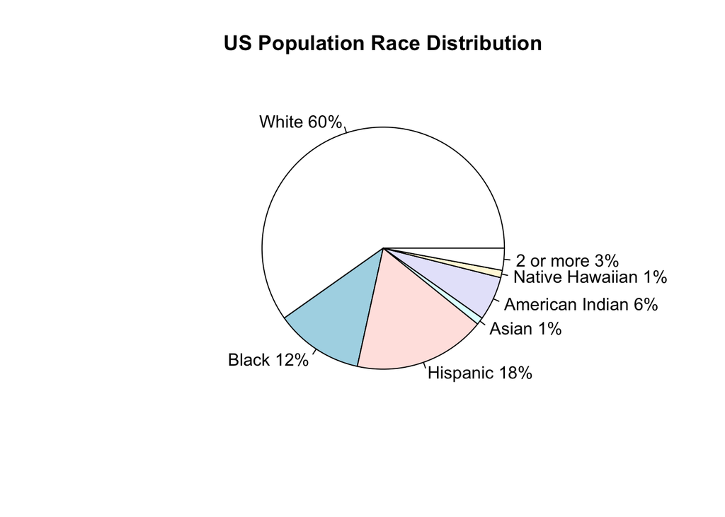

```r
slices <- c(61/100, 12/100, 18/100, 1/100, 6/100, 1/100,
    3/100)
lbls <- c("White", "Black", "Hispanic", "Asian", "American Indian",
    "Native Hawaiian", "2 or more")
pct <- round(slices/sum(slices) * 100)
lbls <- paste(lbls, pct)
lbls <- paste(lbls, "%", sep = "")
pie(slices, labels = lbls, main = "US Population Race Distribution")
```

We find that African Americans make up only 12% of the entire US population.

Now I would like to investigate what percentage of Actors in the US are African American.

# Demographics of US Actors Population

```r
DATAUSA <- read.csv(url("https://github.com/tariq1996/QTM/blob/master/Data%20USA%20-%20Bar%20Chart%20of%20Race%20%26%20Ethnicity%20for%20Actors-1.csv?raw=true"))

library(readxl)
DATAUSA <- read_excel("~/Desktop/DATAUSA.xlsx")

MOVIEDATA = DATAUSA %>% group_by(race_name) %>% summarise(avg = mean(num_ppl,
    na.rm = T))

round(MOVIEDATA$avg, digits = 2)
```

```
## [1]    20.00   112.50  1441.33  3874.33    95.00    97.00   769.67  1112.33
## [9] 24151.67
```

```r
stargazer(MOVIEDATA, type = "text", header = FALSE,
    title = "Population Race Distribution", summary = FALSE,
    rownames = FALSE)
```

```
##
## Population Race Distribution
## ==========================================================
## race_name                                       avg
## ----------------------------------------------------------
## Alaska Native                                    20
## American Indian                                112.5
## Asian                                     1441.33333333333
## Black or African American                 3874.33333333333
## Native Hawaiian or Other Pacific Islander        95
## Other Native American                            97
## Two or more races                         769.666666666667
## Unknown                                   1112.33333333333
## White                                     24151.6666666667
## ----------------------------------------------------------
```

[figure not shown]

```r
slices <- c(20/3164, 1441/3164, 3874/3164, 112/3164,
    24151/3164, 95/3164, 770/3164, 1112/3164, 24151/3164,
    97/3164)
lbls <- c("Alaskan", "Asian", "Black", "American Indian",
    "White", "Native Hawaiian", "2 or more", "Unknown",
    "Other Native American")
pct <- round(slices/sum(slices) * 100)
lbls <- paste(lbls, pct)
lbls <- paste(lbls, "%", sep = "")
pie(slices, labels = lbls, main = "Total Actors Race Distribution",
    radius = 1, cex = 0.5)
```

Next, I would like to determine the percentage of African American actors in the Top Movies rated on IMDB and the Oscar Nominated movies.

# Analysis - Part 1

```r
# Creating Vectors

best_movies = c(15, 35, 50)
oscar_movies = c(10, 40, 50)
black_lead = c("Black", "Non-Black", "Total")

# Creating Data Frame

movies_race = data.frame(best_movies, oscar_movies)
```

# Analysis - Part 2

```r
# Calculating the proportion of black leads in Top
# Rated movies
ratio1 <- 15/50

# Calculating the standard error assosciated with
# ratio1
error1 <- ratio1 * (1 - ratio1)/50

# Calculating the proportion of black leads in
# Oscar Nominated Movies
ratio2 <- 10/50

# Calculation of standard error assosciated with
# ratio2
error2 <- ratio2 * (1 - ratio2)/50

# Defining the parameter of interest:
difference <- ratio1 - ratio2
c(difference)
```

```
## [1] 0.1
```

# Analysis - Part 3

Constructing a pie chart to show the difference in proportion of Black and Non-Black Leads in Top 50 movies:

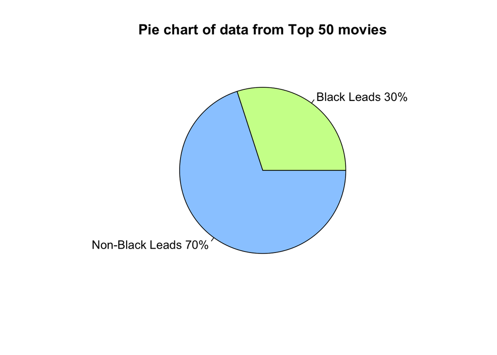

```r
slices <- c(15/60, 35/60)
lbls <- c("Black Leads", "Non-Black Leads")
pct <- round(slices/sum(slices) * 100)
lbls <- paste(lbls, pct)
lbls <- paste(lbls, "%", sep = "")
pie(slices, labels = lbls, col = c("#ccff99", "#99ccff"),
    main = "Pie chart of data from Top 50 movies")
```

Constructing a pie chart to show the difference in proportion of Black and Non-Black Leads in 50 Oscar nominated movies:

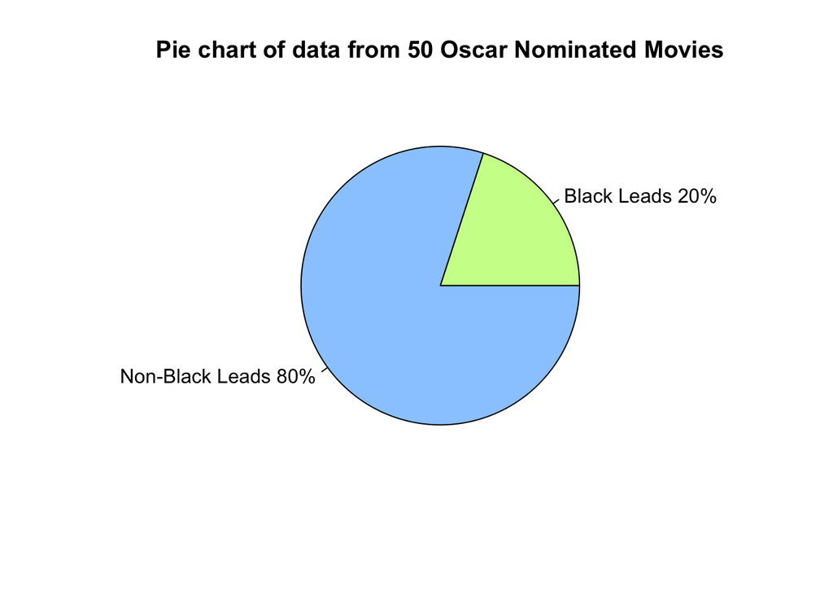

```r
slices <- c(10/50, 40/50)
lbls <- c("Black Leads", "Non-Black Leads")
pct <- round(slices/sum(slices) * 100)
lbls <- paste(lbls, pct)
lbls <- paste(lbls, "%", sep = "")
pie(slices, labels = lbls, col = c("#ccff99", "#99ccff"),
    main = "Pie chart of data from 50 Oscar Nominated Movies")
```

We find that even though the African American population only makes up 12% of the entire US population, they represent almost 30% of the Top 50 Movies on IMDB, and 20% of the Oscar nominated movies.

# Hypothesis Testing

Null Hypothesis = µ1 - µ2 = 0 (Not Guilty of lacking diveristy)

Alternate Hypothesis = µ1 - µ2 > 0 (Guilty of lacking diveristy)

Alpha = 0.05

```r
prop.test(c(15, 10), c(50, 50), correct = FALSE)
```

```
##
##  2-sample test for equality of proportions without continuity
##  correction
##
## data:  c(15, 10) out of c(50, 50)
## X-squared = 1.3333, df = 1, p-value = 0.2482
## alternative hypothesis: two.sided
## 95 percent confidence interval:
##  -0.06860248  0.26860248
## sample estimates:
## prop 1 prop 2
##    0.3    0.2
```

We find that the p-value is 0.2482, which is greater than the our significance level of 0.05 Since our p-value is greater than our alpha level, we fail to reject the Null Hypothesis.

With 95% confidence, we can say that the difference in the Number of Top 50 Movies with Black leads and the Number of Oscar Nominated Movies with Black leads is in between -0.07 and 0.27.